# Diabetes_Data_Analysis

# Univariate Visualzation and Analysis

It is always very hard to interpret the describtive statistics looking at the charts and numeric values. Therefore we will use different visualizations to analyze and interpret the relationship between variables.

First of all we will analyze some of the Univariable visualization.

## - Glucose Distribution

[figure not shown]

## - Blood Pressure Distribution

[figure not shown]

## - Blood Pressure Boxplot

[figure not shown]

We can analyze the distribution of blood pressure and glucose is pretty much normally distributed which can also be verified from the box plot that the mean line is lying right in the middle.

But we can see from the that there are some outling values where the blood pressure is around 122.

## - Skin Thickness Boxplot

[figure not shown]

We can see that 277 observations have skin thickness of 0 where as some of them are having values from 20 to 45. We shows that it is not normally distributed, rather the distribution is right skewed.

## - Insulin Boxplot

[figure not shown]

We can see that around 400 obeservations are having 0 insulin where as the rest of them having a diverse range from 50 to 350

## - BMI Boxplot

[figure not shown]

## - Pregnancies Barchart

[figure not shown]

Since the Pregnancies is a categorical varible, we would not be using histogram for it rather we would use Bar plot. This bar plot shows that the number of 0 and 1 Pregnancies are dominating while it is clearly interpretable that as the number of pregnancies increase the frequency decreass.

## - Outcome Barchart

[figure not shown]

This bar plot explains the class imbalance problem, which clearly shows that the number of observations not having diabetes are around 500 and the one having diabetes are only around 250.

## Multivariate Visualizations and Analysis

```python
#It is very important to analyze the linear relationship between the variables to choose best features for the prediction
#algorithm.

df.corr()
```

|  | Pregnancies | Glucose | BloodPressure | SkinThickness | Insulin | BMI | DiabetesPedigreeFunction | Age | Outcome |
| --- | --- | --- | --- | --- | --- | --- | --- | --- | --- |
| Pregnancies | 1.000000 | 0.129459 | 0.141282 | -0.081672 | -0.073535 | 0.017683 | -0.033523 | 0.544341 | 0.221898 |
| Glucose | 0.129459 | 1.000000 | 0.152590 | 0.057328 | 0.331357 | 0.221071 | 0.137337 | 0.263514 | 0.466581 |
| BloodPressure | 0.141282 | 0.152590 | 1.000000 | 0.207371 | 0.088933 | 0.281805 | 0.041265 | 0.239528 | 0.065068 |
| SkinThickness | -0.081672 | 0.057328 | 0.207371 | 1.000000 | 0.436783 | 0.392573 | 0.183928 | -0.113970 | 0.074752 |
| Insulin | -0.073535 | 0.331357 | 0.088933 | 0.436783 | 1.000000 | 0.197859 | 0.185071 | -0.042163 | 0.130548 |
| BMI | 0.017683 | 0.221071 | 0.281805 | 0.392573 | 0.197859 | 1.000000 | 0.140647 | 0.036242 | 0.292695 |
| DiabetesPedigreeFunction | -0.033523 | 0.137337 | 0.041265 | 0.183928 | 0.185071 | 0.140647 | 1.000000 | 0.033561 | 0.173844 |
| Age | 0.544341 | 0.263514 | 0.239528 | -0.113970 | -0.042163 | 0.036242 | 0.033561 | 1.000000 | 0.238356 |
| Outcome | 0.221898 | 0.466581 | 0.065068 | 0.074752 | 0.130548 | 0.292695 | 0.173844 | 0.238356 | 1.000000 |

## - Age and Blood Pressure Relationship

[figure not shown]

We can observe that the relationship between age and blood pressure is not very strong but there is a tendency of increasing blood pressure with increasing age. A positive relation with very small effect.

## - Skin thickness and Insulin Relationship

[figure not shown]

We can clearly see the positive relationship between the skinthickness and insulin as the value in skinthickness increase the value of insulin on y axis increases.

## - Pregnancies and Outcome Relationship

[figure not shown]

This stacked barplot shows the relationship between two categorical variables the number of pregnancies and the outcome. This is very important visual which demonstrates that as the number of pregnancies increases the outcome tends to be true.

## - Age and Pregnancies Relationship

[figure not shown]

The Age is directly proportional to the number of pregnancies which is an obvoius relation as well and we can verify it from the correlation matrix as well, the correlation is 0.544

## Correlation Matrix Plot

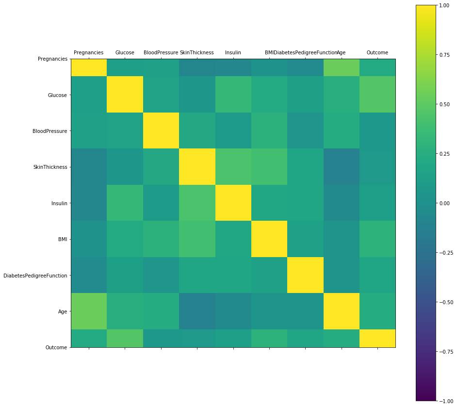

```python
correlations = df.corr()
# plot correlation matrix
fig = plt.figure()
ax = fig.add_subplot(111)
fig.set_size_inches(15, 15)
cax = ax.matshow(correlations, vmin=-1, vmax=1)
fig.colorbar(cax)
ticks = np.arange(0,9,1)
ax.set_xticks(ticks)
ax.set_yticks(ticks)
ax.set_xticklabels(df.columns)
ax.set_yticklabels(df.columns)
plt.show()
```

## Feature Engineering

```python
from sklearn import feature_selection
```

```python
rfe_x = df[['Pregnancies', 'Glucose', 'BloodPressure', 'SkinThickness', 'Insulin',
       'BMI', 'DiabetesPedigreeFunction', 'Age']]
```

```python
from sklearn.feature_selection import RFE
from sklearn.linear_model import LogisticRegression
logreg = LogisticRegression()
rfe = RFE(logreg)
rfe = rfe.fit(rfe_x,df['Outcome'])
print(rfe.support_)
print(rfe.ranking_)
```

```
[ True  True False False False  True  True False]
[1 1 2 4 5 1 1 3]
```

[output not shown]

According to the recursive feature selection which is basically backward feature selection process selects Pregnancies, Glucose, BMI, DiabetesPedigreeFunction as the most important variables in first cluster. Blood Pressure in the second cluster, Age in the third and then the remaining features.